# Attribution Models: Same Journey, Different Conclusions

Which Channel Actually Drove the Sale?

## The Problem

[figure not shown]

Facebook Ad

→

[figure not shown]

Google Ads

→

📧

Email Click

→

💰

Purchase

**The data aren’t good enough to tell us who gets credit.**

So we pick a model — and assign credit as close to reality as we can.

## 5 Attribution Models

First-touch

100% to first touch

Last-touch

100% to last touch

Linear

Equal split across all

Time Decay

More credit near conversion

U-shape

40% · 20% · 40%

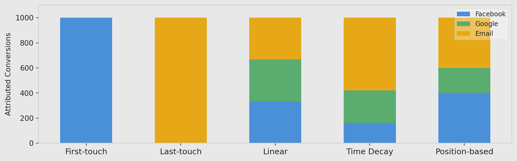

Facebook credit: **0 → 1,000** depending on model chosen. Same data. Very different story.

## How Do We Know Which Model Is Better?

**💡 Spend Validation**

✅ Good Model

Spend ↑ → Attribution ↑

❌ Poor Model

Spend fluctuates → Attribution flat

**🧪 Incrementality Testing**  
Randomly withhold a channel from a control group. Measure the conversion difference.  
A form of A/B testing — the gold standard for measuring true channel impact.

Both methods help us move from *assuming* to *validating*.

## Takeaway

The data alone can’t tell us who drove the sale.

So we pick a model — and **validate it.**

Use **spend validation** as a quick sanity check.  
Use **incrementality testing** when you need the real answer.

Attribution models assign credit.  
Only experiments can prove it.